# Techniki wizualizacji danych - badanie

Mateusz Mazurkiewicz, Wojciech Rosiński, Dawid Stelmach

7 listopada 2017

Badanie zostało przeprowadzone przy użyciu formularza google. Utworzyliśmy 3 wykresy o różnej tematyce, do każdego po kilka pytań. Naszym założeniem było, że ma nie być prosto.

Poniżej umieszczamy krótkie zestawienie wyników oraz formularz wraz z wynikami do wglądu:

- https://docs.google.com/forms/d/1K6dx3l16yb6ag-HRe4gUcvNumgjBx4PDME9tus2KuCk/edit?usp=sharing

## 1 - wykres kołowy

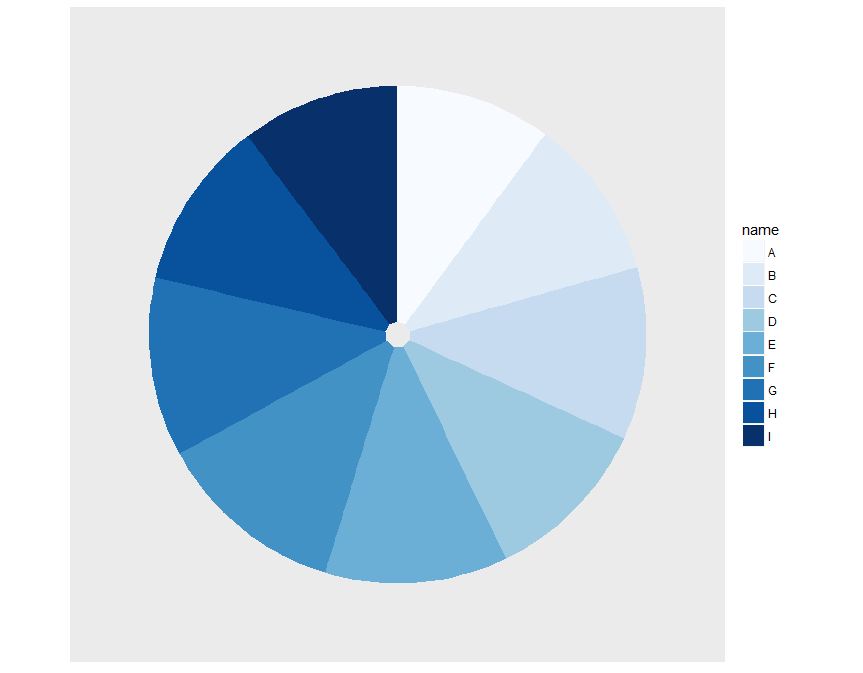

Nie został on powiązany z żadnymi konkretnymi danymi oraz ilość informacji została zredukowana do minimum. Do wykresu dołączone były 3 pytania.

#### 1 *Which parts are the same size? The same letters don’t count and you do not have to duplicate answers.*

Spośród wszystkich kawałków tylko dwa są tej samej wielkości. Są to D i H. Jednak nasi ankietowani byli zupełnie innego zdania.

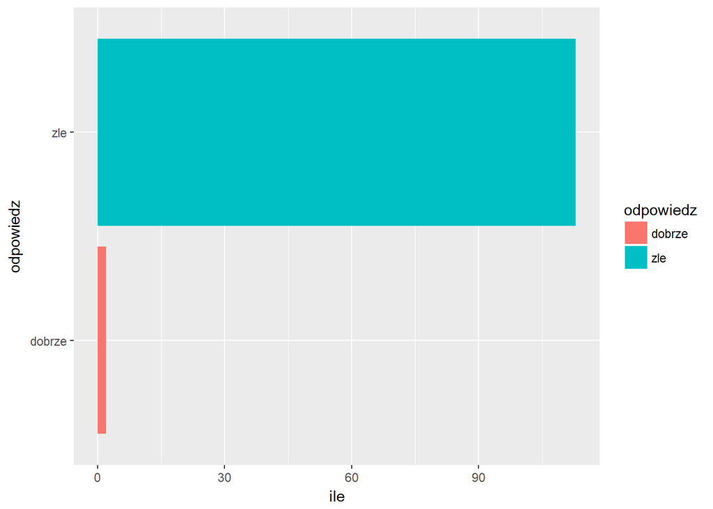

Tak więc na 115 wszystkich oddanych głosów, tylko 2 odpowiedzi były poprawne. Najwięcej głosów zebrały kawałki A oraz I bo 14. Biorąc pod uwagę, że w ankiecie wzięło udział 17 osób, jest to bardzo pokaźny wynik.

#### 2 *Order slices in descending order.*

Tutaj nikomu nie udało się ponumerować w dobrej kolejności od początku do końca. Jeśli chodzi o pojedyncze poprawne strzały, sytuacja przedstawia się następująco:

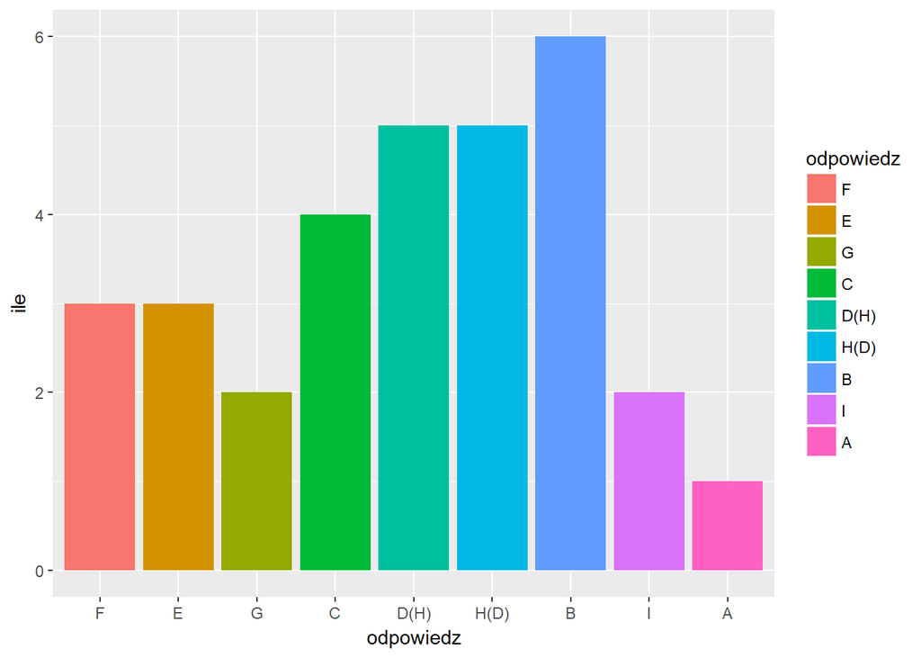

Ciekawym faktem jest, że bardzo dużo osób podało odwrotną kolejność A oraz I. **I = 46**, **A = 45** natomiast zdaniem aż **9** osób **I** jest najmniejsze a zdaniem **7** **A** jest drugie od końca. Jednak czy przekazem podprogowym była tutaj kolejność alfabetyczna i potencjalna równość, czy też zaważyły na tym kolory (**I** jest bardzo ciemne, natomiast **A** bardzo jasne) tego się nie dowiemy.

#### 3 *If you know that the biggest part is 55 and the smallest 45, which slices differ exactly by 5?*

W tym przypadku mieliśmy 3 pary:

- **A_C**: 45-50
- **C_F**: 50-55
- **B_G**: 47-52

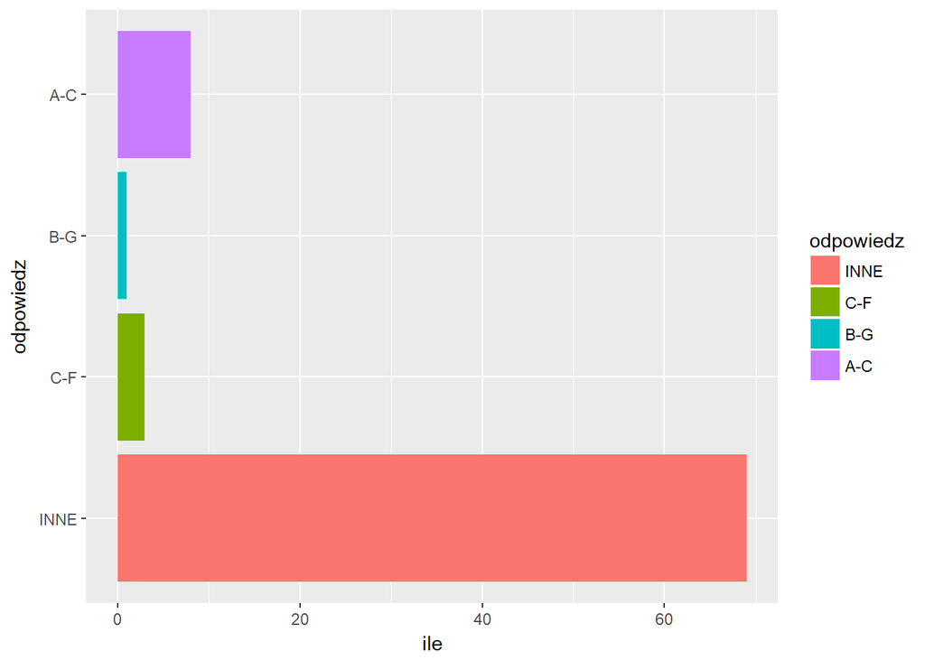

Na 81 oddanych strzałów, 12 zostało oddanych celnie. Biorąc pod uwagę początkowe założenia i brak jakichkolwiek danych ułatwiających identyfikację, wynik ten i tak wydaje się zaskakująco wysoki.

## 2 - wykres słupkowy: wysokość długu krajowego.

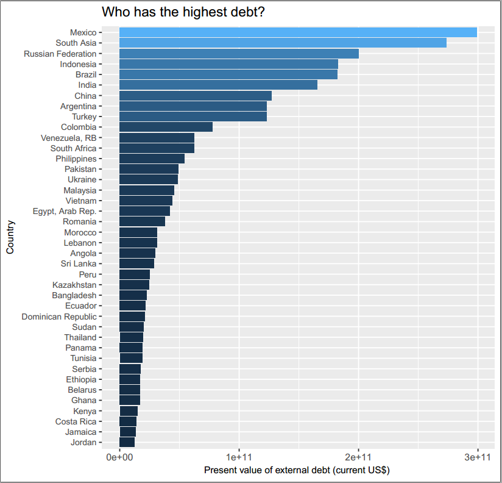

Dane pochodzą z https://data.worldbank.org/data-catalog/international-debt-statistics

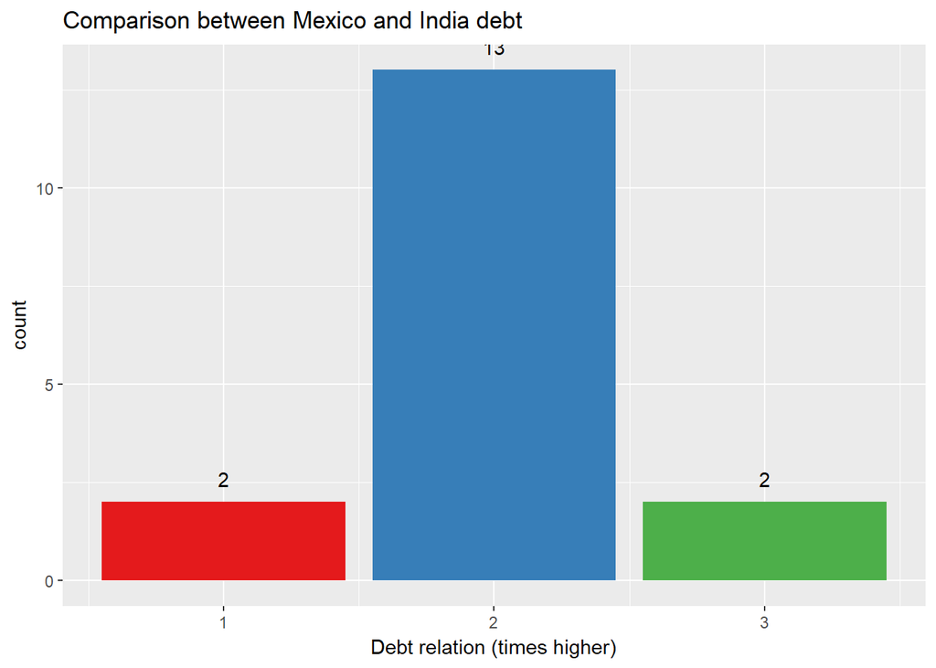

```r
q1
```

Pytanie pierwsze: *How many times higher is Mexico’s external debt in comparison to India’s external debt (approximately) ?* 13 osób spośród 17 odpowiedziało poprawnie, wysokość długu Meksyku w stosunku do Indii rzeczywiście jest około 2-krotnie większa.

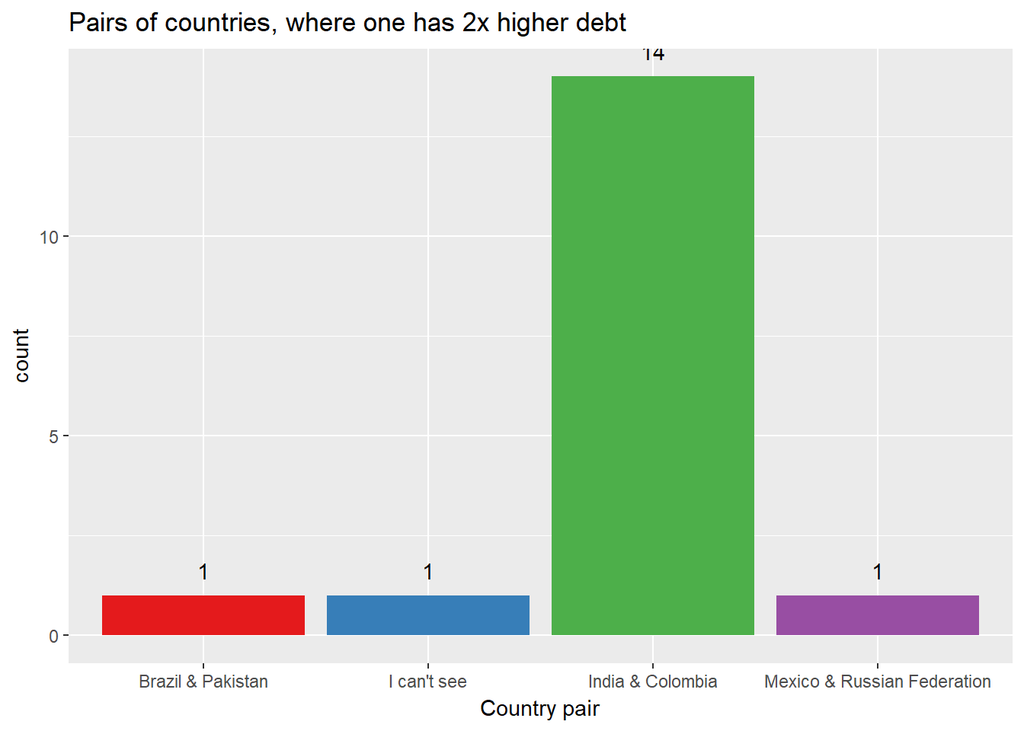

```r
q2
```

Pytanie drugie: *In which pair of the countries one’s debt is approximately two times higher than debt of the other one?* 14 osób spośród 17 odpowiedziało poprawnie, rzeczywiście Indie posiadają dług dwukrotnie przewyższający dług Kolumbii. Zdecydowana większość osób i w tym przypadku nie ma problemu z oceną stosunku ilościowego między dwoma wartościami przedstawionymi w postaci słupków.

## 3 - heatmapa: średnia temperatura roczna.

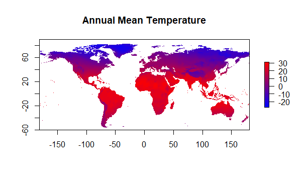

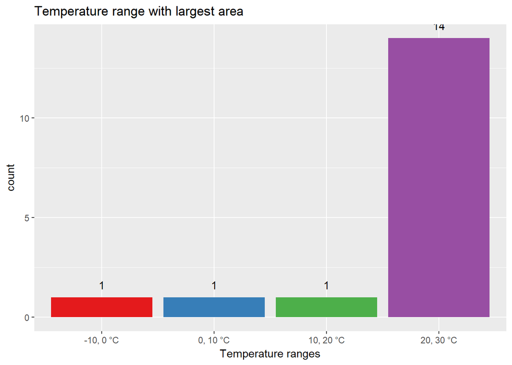

```r
h1
```

Pytanie pierwsze: “Which temperature range has the largest total area?”. Poprawna odpowiedź to ‘20, 30 st. C’. Udzieliło jej 14 z 17 osób - dość duża grupa.

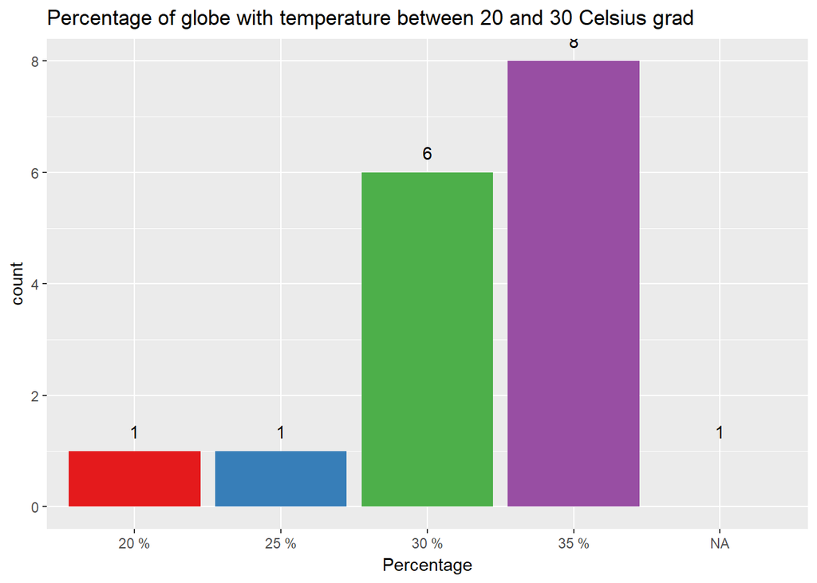

```r
h2
```

Pytanie drugie: “What part of globe has temperature range between 20 °C and 30 °C? (approximately)”. Prawidłowa odpowiedź to 30% (tak dokładnie 32.2%). Udzieliło jej 6 na 17 osób, ale kolejne 8 osób, które zaznaczyło 35% również było bardzo blisko.

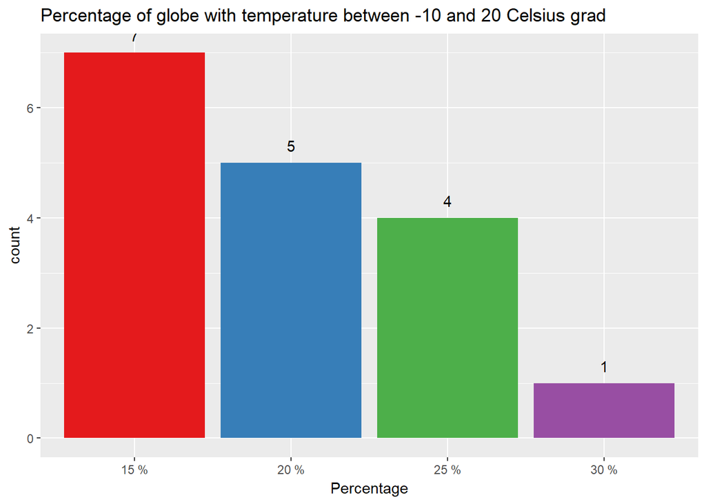

```r
h3
```

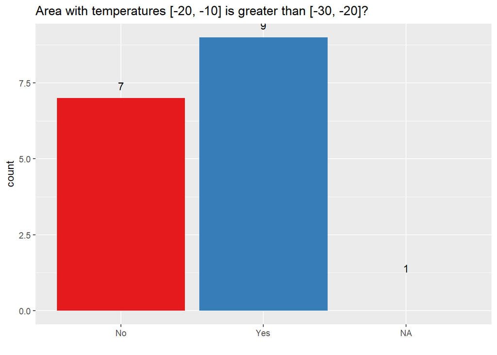

```r
h4
```

Pytanie czwarte: “Is total area with temperature range between -20 °C and -10 °C bigger than total area with temperature range between -30 °C and -20 °C”. Odpowiedź brzmiała ‘tak’TAK’, ale powierzchnie różniły się zaledwie o kilka punktów procentowych, więc pomyłki były zrozumiałe. Poprawnej odpowiedzi udzieliło 9 na 17 odób.

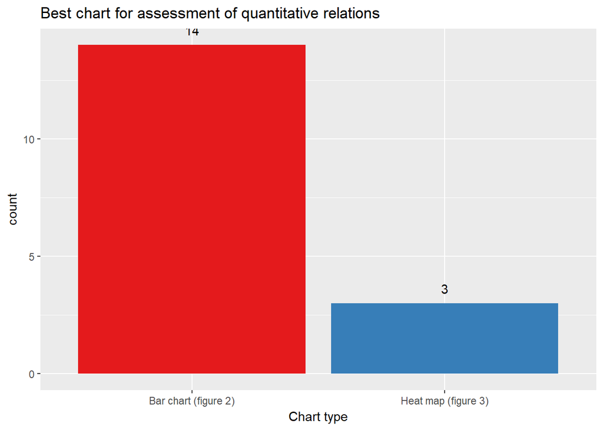

```r
pc
```

Potwierdzenie, że właśnie wykres słupkowy okazał się najbardziej przyjaznym, jeśli chodzi o określanie relacji między wartościami znajdujemy w podsumowującym pytaniu: *On which chart were quantitative relations easiest to assess?* Nikt nie wybrał wykresu kołowego, 14 osób wybrało słupkowy. Co jednak najciekawsze, 3 osoby stwierdziły, że najłatwiej ocenić stosunek ilościowy było im na mapie.